# Ethics In Predictive Policing

12/10/25

Chris Hussey

## Introduction: AFST & Ethical Questions

- My original AFST project examined how administrative data, including welfare, schooling, juvenile justice, feeds into a child risk-scoring algorithm.
- Key ethical issues: consent, representativeness, function creep, racial proxies.
- I wondered how I could connect this to my thesis topic which looks at our diminished capacity to consent to state coercion enabled by private actors.
- Today: I extend that analysis using **NYPD stop-and-frisk data** to indicate that a similar structure is operating inside predictive policing.

## Administrative Data ≠ Crime Data

NYC Open

- Stop-and-frisk is not a measure of crime.
- It is a measure of **policing activity**: who police stop, search, and arrest.
- This makes it structurally similar to AFST data:
  - It reflects **visibility to the state**,
  - not objective risk.
- Visualizing this data makes the bias visible.

## Data Set

```
# A tibble: 6 × 11
  race              stops frisks searches arrests weapons prop_stops prop_frisks
  <chr>             <int>  <int>    <int>   <int>   <int>      <dbl>       <dbl>
1 BLACK             14662   9584     5974    3955    2155    0.601       0.646
2 WHITE HISPANIC     5177   2915     2067    1482     679    0.212       0.197
3 BLACK HISPANIC     2485   1555      940     634     377    0.102       0.105
4 WHITE              1367    466      606     531     116    0.0560      0.0314
5 ASIAN / PACIFIC …   435    184      213     172      44    0.0178      0.0124
6 MIDDLE EASTERN/S…   228    106       82      67      24    0.00935     0.00715
# ℹ 3 more variables: prop_searches <dbl>, prop_arrests <dbl>,
#   prop_weapons <dbl>
```

## Who Gets Stopped?

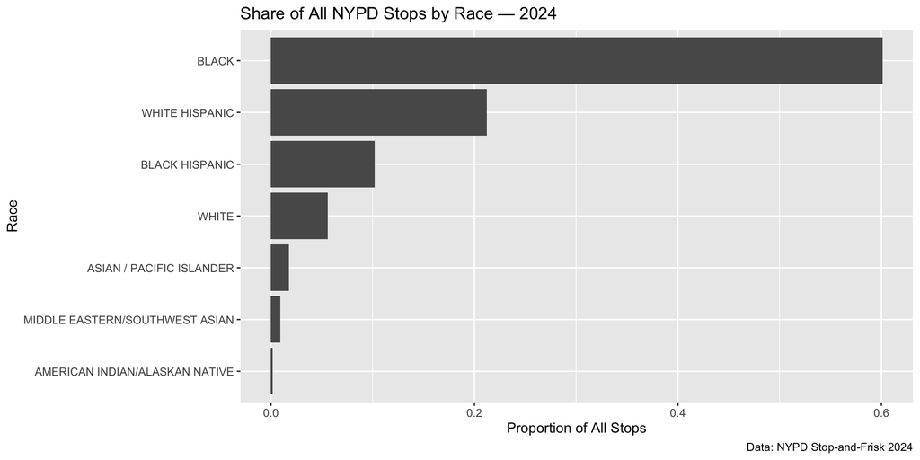

## Who Gets Arrested?

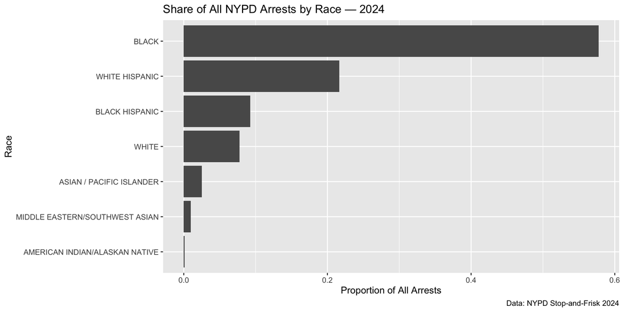

## Within-Group Escalation: Black Stops → Arrests

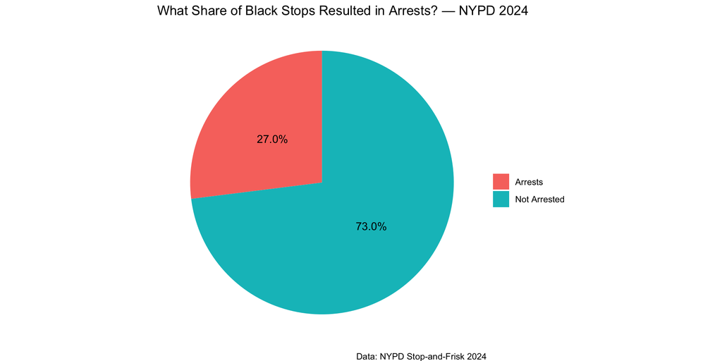

## **Predictive Policing in 60 Seconds**

- Tools like **PredPol/Geolitica** use past incident reports (and sometimes stops/arrests) to forecast “high-risk” locations.
- But if the data reflects **racially skewed enforcement**, predictions simply reroute police to the same communities.
- Research shows:
  - <1% accuracy in Plainfield, NJ (The Markup)
  - Reinforced racial patterns in Oakland (Lum & Isaac)
  - Programs discontinued in LA and Chicago after civil-rights audits.
- The algorithm learns **policing**, not crime.

## **How This Mirrors AFST**

### **Same structural pattern:**

- **Representativeness:**
  - AFST sees families in public systems.
  - Policing algorithms see people whom police choose to stop.
- **Function Creep:**
  - AFST repurposes welfare/education records for prediction.
  - Policing repurposes stop/arrest data for patrol forecasts.
- **Proxies for Race:**
  - Neighborhood, school discipline, benefits = racialized proxies.
  - Stop locations, arrest histories = racialized policing proxies.
- **Feedback Loop:**
  - More intervention = more data = more predicted risk = more intervention.

## **Ethical Evaluation**

Using Data Feminism’s lens:

- **Examine Power:** These systems amplify the visibility of groups already heavily monitored.
- **Challenge Neutrality:** Risk scores and “hotspots” are institutional histories disguised as objective predictions.
- **Consider Harm:** Algorithmic decisions escalate surveillance and state intervention in marginalized communities.

## **Potential Conclusions?**

Predictive systems built from institutional data seem to more accurately measure **institutional behavior**. The AFST and NYPD data sets indicate the same structural logic, that data becomes a weapon when it encodes unequal power.

Thank You!